# EDA Homework 3

Joe Stoica, Conor Devins

9/14/2018

We’ll try transfomations and modeling of the food web data, described in Cleveland starting on page 58.

It is available in the lattice.RData file, which you can download from http://ml.stat.purdue.edu/stat695t/R/lattice.RData.

The data set is called food.web, and it contains two variables – mean.length, a positive, continuous variable giving the average length of the food web, and – dimension, a categorical variable taking values Mixed, Two, and Three, giving the type of food web. We will be interested in how mean.length varies with dimension.

#### 1. Make a Q-normal plot of mean.length, faceted out by dimension.

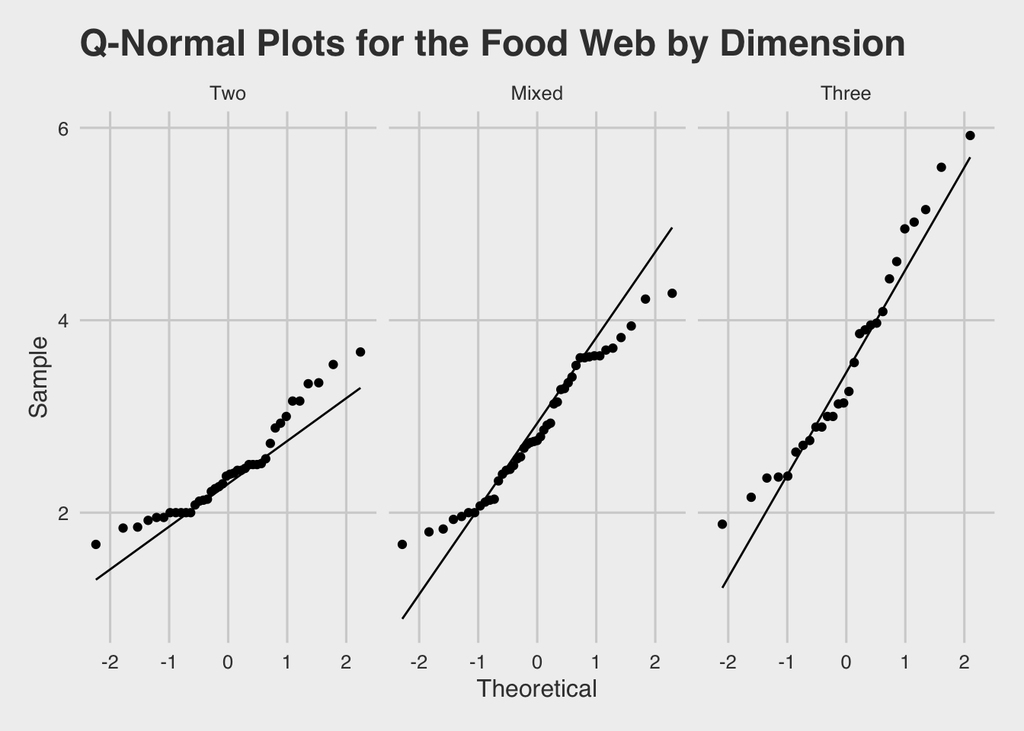

```r
food.web <- readRDS("food_web.RDS")

food.web %>%
  ggplot(aes(sample = mean.length)) +
  stat_qq() +
  geom_qq_line() +
  facet_grid(. ~ factor(dimension)) +
  theme_fivethirtyeight() +
  theme(axis.title = element_text()) +
  xlab("Theoretical") +
  ylab("Sample") +
  ggtitle("Q-Normal Plots for the Food Web by Dimension")
```

#### 2. Let’s try some transformations of mean.length. Make Q-normal plots of log-transformed mean.length and power-transformed mean.length, with power −1 (so the inverse transformation), faceted out by dimension. Do either of these transformations make mean.length look more normally distributed?

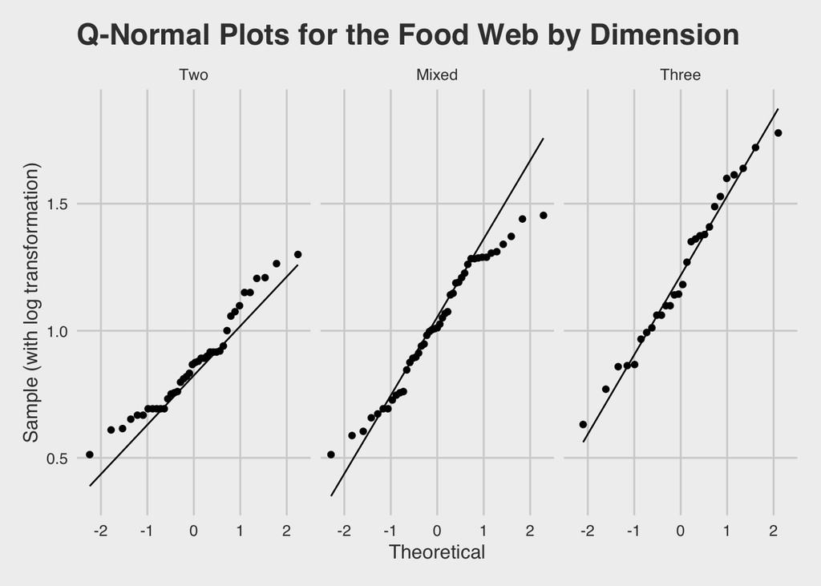

```r
food.web %>%
  mutate(log.mean.length = log(mean.length)) %>%
  ggplot(aes(sample = log.mean.length)) +
  stat_qq() +
  geom_qq_line() +
  facet_grid(. ~ factor(dimension)) +
  theme_fivethirtyeight() +
  theme(axis.title = element_text()) +
  xlab("Theoretical") +
  ylab("Sample (with log transformation)") +
  ggtitle("Q-Normal Plots for the Food Web by Dimension")
```

The log transformation definitely makes the data seem more normally distributed, especially in the dimension mixed and dimension three categories.

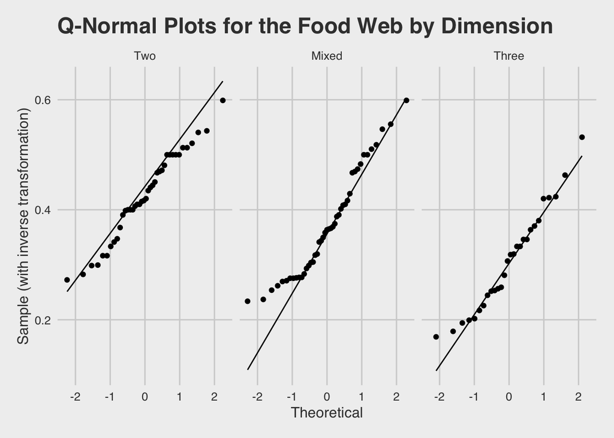

```r
food.web %>%
  mutate(inverse.mean.length = mean.length^-1) %>%
  ggplot(aes(sample = inverse.mean.length)) +
  stat_qq() +
  geom_qq_line() +
  facet_grid(. ~ factor(dimension)) +
  theme_fivethirtyeight() +
  theme(axis.title = element_text()) +
  xlab("Theoretical") +
  ylab("Sample (with inverse transformation)") +
  ggtitle("Q-Normal Plots for the Food Web by Dimension")
```

The inverse transformation looks like it also makes it more normal. Dimension two looks relatively a little worse, but mixed and three lie along the line much better than in either of the plots.

#### 3. Let’s model the inverse of mean.length as a function of dimension. Create a linear model with the inverse of mean.length as the response (y variable) and dimension as the predictor (x variable).

```r
mod <- lm(mean.length^-1~0+dimension, data=food.web)
summary(mod)
```

```
##
## Call:
## lm(formula = mean.length^-1 ~ 0 + dimension, data = food.web)
##
## Residuals:
##       Min        1Q    Median        3Q       Max
## -0.153296 -0.078453 -0.006745  0.062865  0.227094
##
## Coefficients:
##                Estimate Std. Error t value Pr(>|t|)
## dimensionTwo    0.42578    0.01421   29.96   <2e-16 ***
## dimensionMixed  0.37171    0.01340   27.75   <2e-16 ***
## dimensionThree  0.30751    0.01698   18.11   <2e-16 ***
## ---
## Signif. codes:  0 '***' 0.001 '**' 0.01 '*' 0.05 '.' 0.1 ' ' 1
##
## Residual standard error: 0.08987 on 110 degrees of freedom
## Multiple R-squared:  0.9478, Adjusted R-squared:  0.9463
## F-statistic: 665.1 on 3 and 110 DF,  p-value: < 2.2e-16
```

As dimension increases from Two to Mixed to Three, the mean of the inverse of mean length decreases from 0.426 to 0.372 to 0.307.

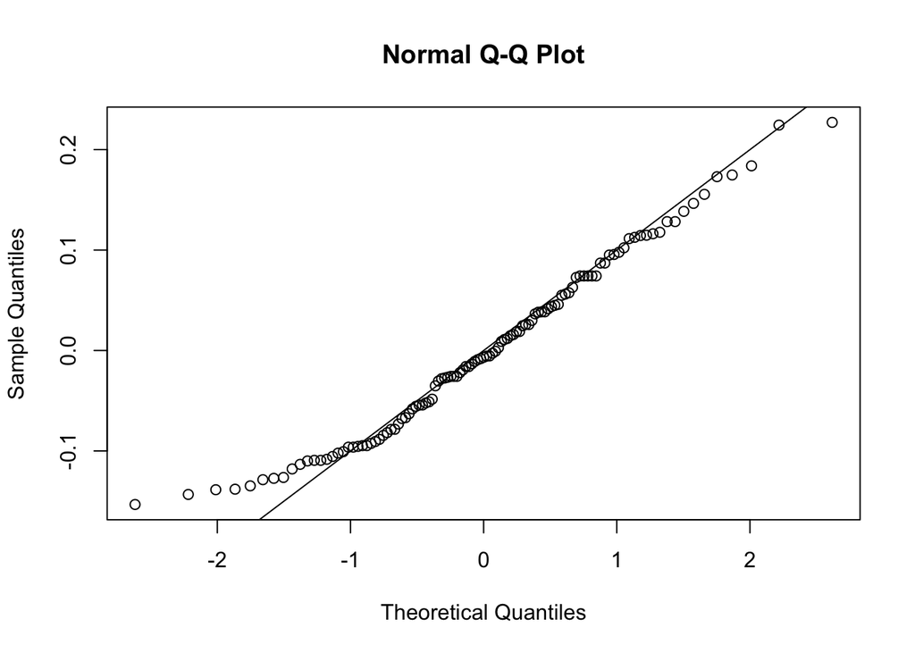

```r
qqnorm(resid(mod))
abline(0, .1)
```